# **[Universidade Federal Rural de Pernambuco](http://ufrpe.br/)** **[Departamento de Matemática](http://www.dm.ufrpe.br/)** **[Disciplina: Cálculo M I](https://sites.google.com/site/ricardonunesmachadojr/disciplinas/c%C3%A1lculo-mi)** **[Prof. Ricardo Machado](https://sites.google.com/site/ricardonunesmachadojr/)**

## [Índice de Aulas](https://sagectu.com.br/calculo1.github.io/index.html) Aula 6

## Taxa de variação Derivada da função Inversa

# Referências:

[figure not shown]

[figure not shown]

### Observação: Nota de aula produzida usando o software [SageMath](http://www.sagemath.org/), usando o notbook [Jupyter](https://jupyter.org/). Use o SageMathCell com vários exemplos em: sagectu.com.br/sagecell.html

## 1 - Taxa de variação

## Seja a função $y = f(x)$. A razão $$ \frac{f(x+\Delta x)-f(x)}{\Delta x} $$ é a *taxa média de variação de* $f$ entre $x$ e $x+\Delta x$. A derivada de $f$, em $x$ é também denominada de *taxa de variação de* $f$ em $x$. $\blacksquare$

## Exemplo 1 O raio de uma esfera está variando, com o tempo, a uma taxa constante de $5$ (m/s). Com que taxa está variando o volume da esfera no instante em que $r = 2$ (m)?

## Solução (Exemplo 1) Seja $t_0$ o instante em que $r=2$. Queremos calcular $\displaystyle \frac{dV}{dt}\bigl\vert_{t=t_0} $ . Sabemos que $V = \dfrac{4}{3}\pi r^3$. Pela regra da cadeia $$ \frac{dV}{dr} = \frac{dV}{dr}\cdot\frac{dr}{dt}. $$ Como $\frac{dV}{dr} = 4\pi r^2$ e $\frac{dr}{dt} = 5$, temos $$ \frac{dV}{dr} = 20\pi r^2. $$ Para $t=t_0$, $r=2$, logo $\displaystyle \frac{dV}{dt}\bigl\vert_{t=t_0} = 20\cdot \pi\cdot(2)^2 = 80\pi~ (m^3/s)$ $\blacksquare$

## Velocidade e Aceleração Suponhamos que uma partícula se desloca sobre o eixo $x$ de acordo com uma função de posição $x = f(t)$. A *velocidade média* da partícula entre os instantes $t$ e $t+\Delta t$ é definida pelo quociente $$ \frac{f(t+\Delta t)-f(t)}{\Delta t}, \text{ onde } \Delta x = f(t+\Delta t)-f(t)$$ é o deslocamento da partícula entre os instantes $t$ e $t+\Delta t$. A *velocidade* da partícula no instante $t$ é definida como sendo a derivada (caso exista) de $f$ em $t$. Assim, $v(t) = f'(t)$ A *aceleração* no instante $t$ é definida como sendo a derivada em $t$ da função $v = v(t)$; Assim, $a(t) = v'(t) = f''(t)$ $\blacksquare$

## Exercício 1 Uma partícula move-se (de acordo com a animação abaixo) sobre o eixo $x$ de modo que no instante $t$ a posição $x$ é dada por $x = \cos(3t)$, $t\geq 0$. Suponha $x$ dado em metros e $t$ em segundos.

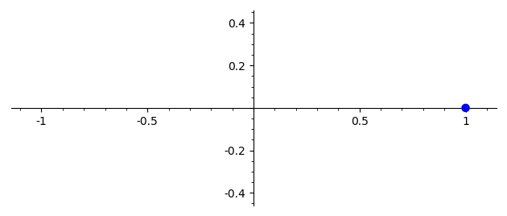

```python
anima_ponto(cos(3*x), (0, 2*pi/3), (-1, 1), 0.05)
```

## a) Determine as posições ocupadas pela partícula nos instantes $t=0$, $t=\frac{\pi}{6}$, $t=\frac{\pi}{3}$, $t=\frac{\pi}{2}$, $t=\frac{2\pi}{3}$. b) Qual a velocidade no instante $t$? c) Qual a aceleração no instante $t$? d) Esboce o gráfico da função de posição.

```python
t = var('t')
f = cos(3*t)
```

```python
f(0), f(pi/6), f(pi/3), f(pi/2), f(2*pi/3)
```

```
(1, 0, -1, 0, 1)
```

```python
diff(f, t).show()
```

$$\newcommand{\Bold}[1]{\mathbf{#1}}-3 \, \sin\left(3 \, t\right)$$

```python
diff(f, t, 2).show()
```

$$\newcommand{\Bold}[1]{\mathbf{#1}}-9 \, \cos\left(3 \, t\right)$$

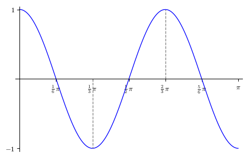

```python
p1 = plot(f, (0, pi), aspect_ratio=1, tick_formatter=pi, ticks=[[pi/6, pi/3, pi/2, 2*pi/3, 5*pi/6, pi],[1, -1]], figsize=[5,5])
l1 = line(((pi/3, 0),(pi/3, -1)), color='gray', linestyle='--')
l2 = line(((2*pi/3, 0),(2*pi/3, 1)), color='gray', linestyle='--')
(p1+l1+l2)
```

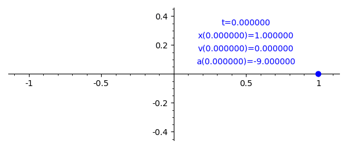

```python
anima_ponto(cos(3*x), (0, 2*pi/3), (-1, 1), 0.05, info=True)
```

## Exercício 2 Uma partícula move-se sobre o eixo $x$ (de acordo com a animação abaixo) de modo que no instante $t$ a posição $x$ é dada por $x = 3+2t-t^2$, $t\geq 0$.

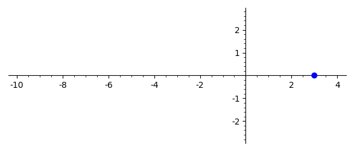

```python
anima_ponto(3+2*x-x^2, (0, 4.5), (-10, 4), 0.05)
```

## a) Qual a velocidade no instante $t$? b) Qual a aceleração no instante $t$? c) Estude a variação de sinal de $v(t)$. d) Esboce o gráfico da função de posição.

```python
t, v, a = var('t, v, a')
f = 3+2*t-t^2
```

```python
(v==diff(f, t)).show()
```

$$\newcommand{\Bold}[1]{\mathbf{#1}}v = -2 \, t + 2$$

```python
(a == diff(f, t, 2)).show()
```

$$\newcommand{\Bold}[1]{\mathbf{#1}}a = \left(-2\right)$$

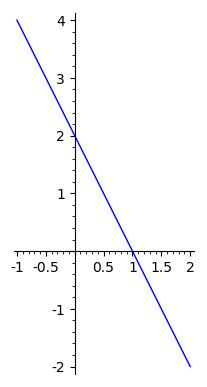

```python
plot(-2*t+2, (t, -1, 2), figsize=[4, 4], aspect_ratio=1)
```

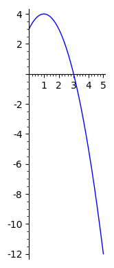

```python
plot(3+2*x-x^2, (0, 5), aspect_ratio=1)
```

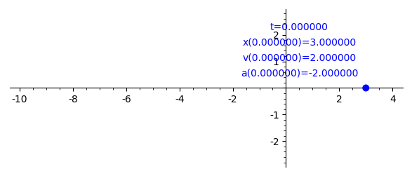

```python
anima_ponto(3+2*x-x^2, (0, 4.5), (-10, 4), 0.05, info=True)
```

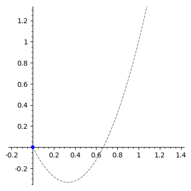

```python
anima_pontoxy(x, 3*x^2-2*x, (0, 1.2), (-0.1, 1.3), 0.05)
```

## 2 - Derivada da função inversa

## Teorema Seja $f$ uma função inversível com inversa $f^{-1}$. Se $f$ é derivável em um ponto $x$ e $f'(x)\neq 0$, então sua inversa é também derivável em $y = f(x)$. Além disso: $$ (f^{-1})'(y) = \frac{1}{f'(x)}. $$

## Demonstração: Como $f$ é inversíver e derivável em $x$, com $f'(x)\neq0$, sabemos que $$ y=f(x) \Rightarrow \frac{dy}{dx} = (f(x))' $$ e $$ f^{-1}(y)=f^{-1}\left(f(x)\right) \Rightarrow x=f^{-1}(y) \Rightarrow \frac{dx}{dy} = \left(f^{-1}(y)\right)' $$ Como $$ f^{-1}\left(f(x)\right) = x$$ Derivando esta última identidade em relação a $x$ e usando a regra da cadeia, obtemos: $$ (f^{-1}(\underbrace{f(x)}_{=y}))'\cdot f'(x) = 1 $$ Portanto $$ (f^{-1})'(y) = \frac{1}{f'(x)}. $$ $\blacksquare$

## Exemplo 2 Seja $f:\mathbb{R}\rightarrow \mathbb{R}$ uma função definida por $$ f(x) = x^5+5x^3+2x-4. $$ Encontre a derivada de $f^{-1}$ no ponto $f(1)$.

## Solução Como $ f' = {5x^4+15x^2+2} $, temos que $f$ é uma função crescente (ainda não foi visto esse assunto), portanto $f$ é sobrejetiva. Dessa forma, como $f(1) = 4$, temos $$ (f^{-1})'(f(1)) = (f^{-1})'(4) = \frac{1}{f'(1)} = \frac{1}{22}. $$ $\blacksquare$

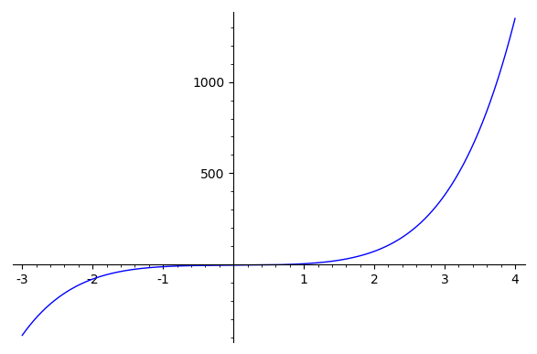

```python
plot(x^5+5*x^3+2*x-4, (-3, 4))
```

## Exemplo 3 (Derivada do arco-seno). Calcule $\text{arcsen}'(x)$, com $x\in \left[ -\frac{\pi}{2}, \frac{\pi}{2} \right]$.

## Solução Como $\text{arcsen}(x)$ é contínua e é a inversa de $f(x) = \text{sen}(x)$ em $x\in \left[ -\frac{\pi}{2}, \frac{\pi}{2} \right]$, temos $$ \text{arcsen}'(x) = \frac{1}{f'(\text{arcsen}(x))} = \frac{1}{\cos(\text{arcsen}(x))}~~~~~~ (\clubsuit) $$ pois, $f'(x) = \cos(x)$. Sabemos que $$ \cos(a)^2 + \text{sen}(a)^2 = 1 $$ Para $a = \text{arcsen}(x)$, temos $$ \cos^2(\text{arcsen}(x)) + \underbrace{\text{sen}^2(\text{arcsen}(x))}_{x^2} = 1 $$ segue $$ \cos^2(\text{arcsen}(x)) = 1 -x^2 \Rightarrow \cos(\text{arcsen}(x)) = \sqrt{1 -x^2} ~~~~ (\clubsuit\clubsuit)$$ pois $\text{arcsen}(x)\in \left[ -\frac{\pi}{2}, \frac{\pi}{2} \right]$. Substituindo $(\clubsuit\clubsuit)$ em $(\clubsuit)$ temos $$ \text{arcsen}'(x) = \frac{1}{\cos(\text{arcsen}(x))} = \frac{1}{\sqrt{1-x^2}}, ~~~ -1<x<1. $$ $\blacksquare$

## Exercício 4 Determine a derivada. a) $y = \text{arcsen}(x^2)$ b) $y = \text{arctan}(x)$ c) $f(x) = x\cdot \text{arctan}(3x)$ (ver melhor esse)

[figure not shown]

```python
diff(arcsin(x^2)).show()
```

$$\newcommand{\Bold}[1]{\mathbf{#1}}\frac{2 \, x}{\sqrt{-x^{4} + 1}}$$

```python
diff(arctan(x)).show()
```

$$\newcommand{\Bold}[1]{\mathbf{#1}}\frac{1}{x^{2} + 1}$$

```python
diff(x*arctan(3*x)).show()
```

$$\newcommand{\Bold}[1]{\mathbf{#1}}\frac{3 \, x}{9 \, x^{2} + 1} + \arctan\left(3 \, x\right)$$